# MLB Payroll analysis

Group 9 Yun An Chen, Hsin Yun Li, Po wei Lin

2025-10-31

# 1 Importing and Exploring the Dataset

```r
#Import the dataset
raw_url <- "https://raw.githubusercontent.com/pwlinbernie/MLB-payroll-analysis/refs/heads/main/mlb_payrolls.csv"
mlb <- read_csv(raw_url)

#check
dim(mlb)
```

```
## [1] 420  12
```

```r
head(mlb)
```

| Team | Team Name | Year | Average Age | Total Payroll Allocations | Active 26-Man | Injured | Retained | Buried | Wins | Losses | Postseason |
| --- | --- | --- | --- | --- | --- | --- | --- | --- | --- | --- | --- |
| OAK | Oakland Athletics | 2024 | 26.5 | $62,132,581 | $28,956,713 | $15,581,092 | $15,557,073 | $1,763,221 | 69 | 93 | No Playoffs |
| PIT | Pittsburgh Pirates | 2024 | 27.7 | $84,050,989 | $51,220,210 | $14,524,211 | $15,341,351 | $2,965,217 | 76 | 86 | No Playoffs |
| TB | Tampa Bay Rays | 2024 | 26.8 | $89,707,422 | $37,691,876 | $13,179,262 | $34,675,167 | $1,706,572 | 80 | 82 | No Playoffs |
| DET | Detroit Tigers | 2024 | 26.0 | $96,961,614 | $33,226,992 | $26,677,166 | $36,920,494 | $1,070,295 | 86 | 76 | Wildcard |
| CLE | Cleveland Guardians | 2024 | 26.3 | $105,224,582 | $50,885,032 | $21,120,833 | $22,945,837 | $10,272,880 | 92 | 69 | Division Winner |
| BAL | Baltimore Orioles | 2024 | 28.4 | $109,335,494 | $65,994,548 | $10,808,540 | $30,650,082 | $1,882,324 | 91 | 71 | Wildcard |

```r
glimpse(mlb)
```

```
## Rows: 420
## Columns: 12
## $ Team                        <chr> "OAK", "PIT", "TB", "DET", "CLE", "BAL", "…
## $ `Team Name`                 <chr> "Oakland Athletics", "Pittsburgh Pirates",…
## $ Year                        <dbl> 2024, 2024, 2024, 2024, 2024, 2024, 2024, …
## $ `Average Age`               <dbl> 26.5, 27.7, 26.8, 26.0, 26.3, 28.4, 27.9, …
## $ `Total Payroll Allocations` <chr> "$62,132,581", "$84,050,989", "$89,707,422…
## $ `Active 26-Man`             <chr> "$28,956,713", "$51,220,210", "$37,691,876…
## $ Injured                     <chr> "$15,581,092", "$14,524,211", "$13,179,262…
## $ Retained                    <chr> "$15,557,073", "$15,341,351", "$34,675,167…
## $ Buried                      <chr> "$1,763,221", "$2,965,217", "$1,706,572", …
## $ Wins                        <dbl> 69, 76, 80, 86, 92, 91, 93, 77, 86, 71, 62…
## $ Losses                      <dbl> 93, 86, 82, 76, 69, 71, 69, 85, 76, 91, 10…
## $ Postseason                  <chr> "No Playoffs", "No Playoffs", "No Playoffs…
```

The dataset contains information on each MLB team’s annual payroll and performance from multiple seasons, including total payroll allocations, wins, losses, and postseason results. Before conducting any analysis, it’s essential to understand the data structure and verify that the variables are properly imported.

# 2 Data Cleaning and Variable Preparation

```r
mlb <- mlb |>
    clean_names() |>
    mutate(
      team = coalesce(team, 'team_name'),
      year = as.integer(year),
      payroll = parse_number(total_payroll_allocations),
      active26 = parse_number(active_26_man),
      wins = as.integer(wins),
      losses = as.integer(losses),
      games = wins + losses,
      win_pct = if_else(games > 0, wins / games, NA_real_),
      #postseason
      postseason =na_if(as.character(postseason), ""),
      playoffs_bin = case_when(
        is.na(postseason) ~0L,
        str_detect(str_to_lower(postseason), "no playoffs") ~0L,
        TRUE ~ 1L
      ),
      log_payroll = log(payroll)
)
# check
names(mlb)
```

```
##  [1] "team"                      "team_name"
##  [3] "year"                      "average_age"
##  [5] "total_payroll_allocations" "active_26_man"
##  [7] "injured"                   "retained"
##  [9] "buried"                    "wins"
## [11] "losses"                    "postseason"
## [13] "payroll"                   "active26"
## [15] "games"                     "win_pct"
## [17] "playoffs_bin"              "log_payroll"
```

```r
summary(select(mlb, payroll, active26, wins, losses, win_pct, playoffs_bin))
```

```
##     payroll             active26              wins            losses
##  Min.   : 23478635   Min.   : 10252278   Min.   : 19.00   Min.   : 17.00
##  1st Qu.: 85220920   1st Qu.: 56963032   1st Qu.: 69.00   1st Qu.: 69.00
##  Median :116035246   Median : 83823420   Median : 80.00   Median : 79.00
##  Mean   :127645094   Mean   : 93876306   Mean   : 77.34   Mean   : 77.34
##  3rd Qu.:162204268   3rd Qu.:124147463   3rd Qu.: 90.00   3rd Qu.: 89.00
##  Max.   :341673777   Max.   :260231924   Max.   :111.00   Max.   :121.00
##     win_pct        playoffs_bin
##  Min.   :0.2531   Min.   :0.0000
##  1st Qu.:0.4444   1st Qu.:0.0000
##  Median :0.5000   Median :0.0000
##  Mean   :0.5000   Mean   :0.3429
##  3rd Qu.:0.5583   3rd Qu.:1.0000
##  Max.   :0.7167   Max.   :1.0000
```

```r
sum(is.na(mlb$payroll)); sum(is.na(mlb$active26))
```

```
## [1] 0
```

```
## [1] 0
```

Standardizing column names and converts key variables into numeric formats.

payroll and active26 are parsed as numerical values. win_pct is calculated from total wins and losses. playoffs_bin is created as a binary indicator (1 = made playoffs, 0 = did not). log_payroll is the natural logarithm of payroll, reducing skewness in later analysis.

# 3 Payroll vs. Winning Percentage (Scatterplot with Regression Line)

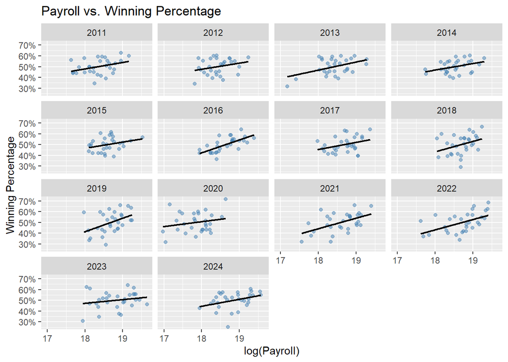

```r
ggplot(mlb, aes(x = log_payroll, y = win_pct)) +
  geom_point(alpha = 0.5, color = "steelblue") +
  geom_smooth(method = "lm", se = FALSE, color = "black", linewidth = 0.8) +
  scale_y_continuous(labels = percent) +
  labs(title = "Payroll vs. Winning Percentage",
       x = "log(Payroll)", y = "Winning Percentage") +
  facet_wrap(~ year)
```

For the scatterplot, we can see that: 1. Across almost all panels, the fitted OLS line has a positive slope, indicating that higher payroll is associated with higher winning percentage in the same season. 2. Teams with very high payrolls cluster toward the upper-right; however, there is substantial vertical spread at many payroll levels, implying that payroll alone does not fully determine performance. 3. A few low-payroll but above-.500 teams (upper-left area) and high-payroll under-.500 teams (lower-right area) illustrate that efficiency, roster construction, injuries, and coaching likely moderate the payroll–performance link.

There is a consistent positive relationship between payroll and winning percentage within seasons, but with meaningful dispersion—payroll helps, yet it does not guarantee success.

# 4 Winning Percentage by Payroll Quartile (Boxplot)

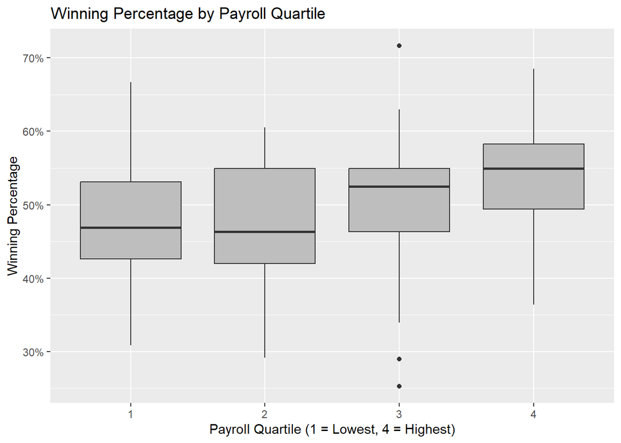

```r
mlb <- mlb |>
  mutate(payroll_q = ntile(payroll, 4))

ggplot(mlb, aes(x = factor(payroll_q), y = win_pct)) +
  geom_boxplot(fill = "gray") +
  scale_y_continuous(labels = percent) +
  labs(title = "Winning Percentage by Payroll Quartile",
       x = "Payroll Quartile (1 = Lowest, 4 = Highest)",
       y = "Winning Percentage")
```

The quartile comparison provides clear descriptive evidence that higher payroll groups tend to win more, yet variance and overlap indicate that other factors (roster age, injuries, development, front-office quality) remain important.